# visualizeR: communication and visualization of uncertainty in seasonal climate prediction

Companion examples to the paper by Frias *et al.* 2018 in Environmental Modelling & Software DOI:10.1016/j.envsoft.2017.09.008

Santander Meteorology Group

07 de Sep 2017

Abstract

This notebook is a companion document to the paper indicated in the title, illustrating the main characteristics and functionalities of package `visualizeR`, an R package for implementing a set of advanced visualization tools for the communication of probabilistic forecasts together with different aspects of forecast quality.  
`visualizeR` is a core package of the climate4R framework.  
**CONTENTS**

# 1 Package installation

```r
install.packages('devtools')
```

```r
devtools::install_github(c("SantanderMetGroup/transformeR",
                           "SantanderMetGroup/visualizeR"))
```

```r
library(visualizeR)
```

# 2 Example data

In this part we will use the built-in datasets included in the package (see `data(package = "visualizeR")` for an overview). Seasonal hindcast and operational predictions are taken from the CFSv2 seasonal forecasting system produced by NCEP (Saha *et al.* 2013). Data from the NCEP-NCAR reanalysis 1 (Kalnay *et al.* 1996) are used as reference for verification. All datasets contain global data for near-surface air temperature for boreal winter (DJF). The hindcast dataset spans the temporal period 1983-2010.

```r
data(tas.cfs)
data(tas.cfs.operative.2016)
data(tas.ncep)
```

In this step, the resolution of all data is downgraded to a 5 degree resolution regular grid, to improve the visualiation at a global scale, and for the sake of brevity in teh calculations.

```r
# Adjusting data spatial resolution to 5º lat-lon resolution
newgrid <- getGrid(tas.cfs)
attr(newgrid, "resX") <- 5
attr(newgrid, "resY") <- 5
lower.res <- function(x, newgrid) {
      interpGrid(x, new.coordinates = newgrid, method = "bilinear", bilin.method = "fields")
}
obs <- lower.res(tas.ncep, newgrid)
hindcast <- lower.res(tas.cfs, newgrid)
forecast <- lower.res(tas.cfs.operative.2016, newgrid)
```

# 3 Bubble plots

For convenience, a text string is generated based on the metadata information to use as subtitle in the different plots:

```r
subtitle <- sprintf("Reference data: NCEP;  Hindcast: CFS (%d members); %d-%d",
                    length(hindcast$Members),
                    getYearsAsINDEX(hindcast)[1],
                    tail(getYearsAsINDEX(hindcast),1)
)
```

In its most basic setup, the only information provided is the most likely tercile, indicated by the color of the bubble:

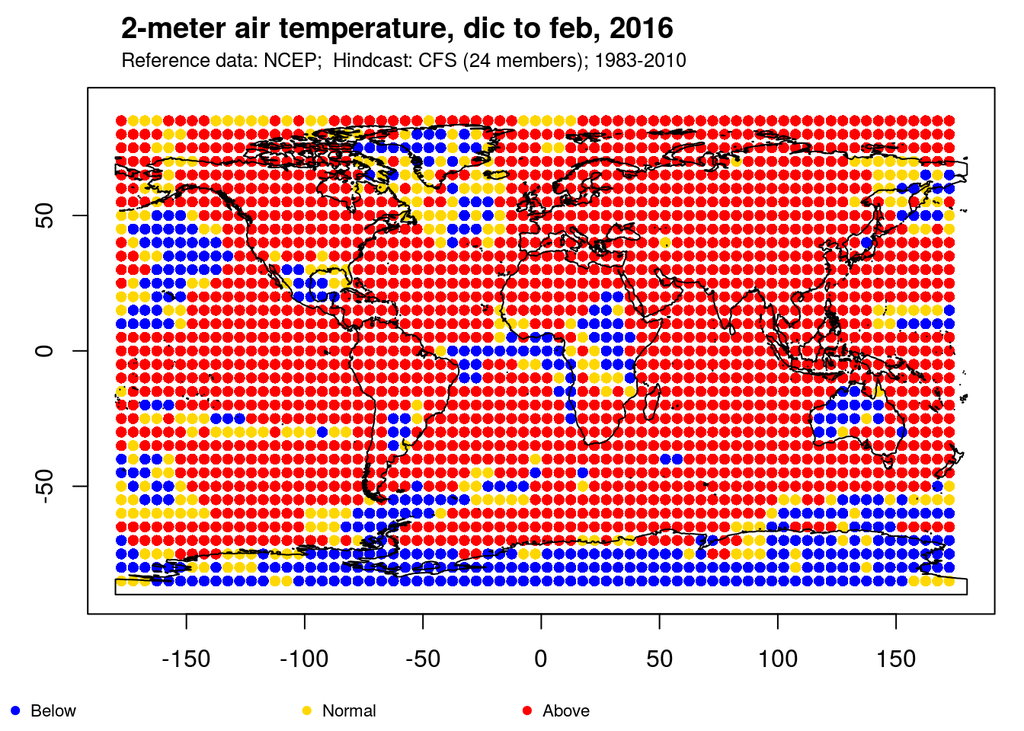

```r
# Only colour of the bubble is plotted indicating the most likely tercile
bubblePlot(hindcast, obs, forecast = forecast,
           bubble.size = 1.5,
           subtitle = subtitle,
           size.as.probability = FALSE,
           score = FALSE
)
```

Note that by default, red indicates the upper tercile and blue the lower (yellow is reserved for the mid tercile). This default behaviour can be reversed for precipitation for a more intuitive interpretation of the plot, or other colors can be alternatively chosen for each tercile (via the argument `t.color`).

An additional information that can be added to the plot is the probability of the most likely tercile. This is represented by the size of the bubble through the argument `size.as.probability`:

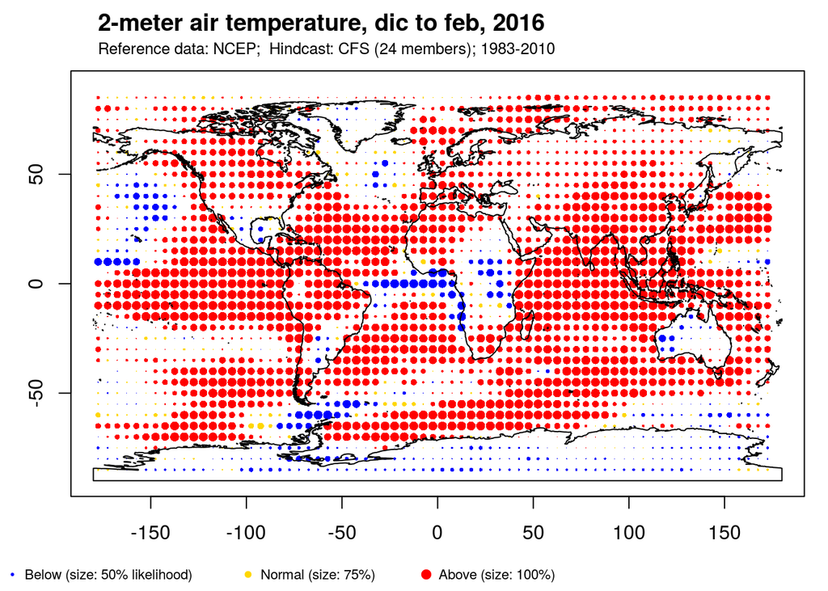

```r
bubblePlot(hindcast, obs, forecast = forecast,
           bubble.size = 1.5,
           subtitle = subtitle,
           size.as.probability = TRUE,
           score = FALSE
)
```

Until now, the forecast information is displayed, but no information regarding the ‘quality’ of the forecasting system is provided. A usual quality measure of accuracy is the ROC skill score (ROCSS). ROCSS can be also indicated in the plot, using to this aim different levels of transparency proportional to the ROCSS value in each grid point. This is automatically done by setting the argument `score` to `TRUE`:

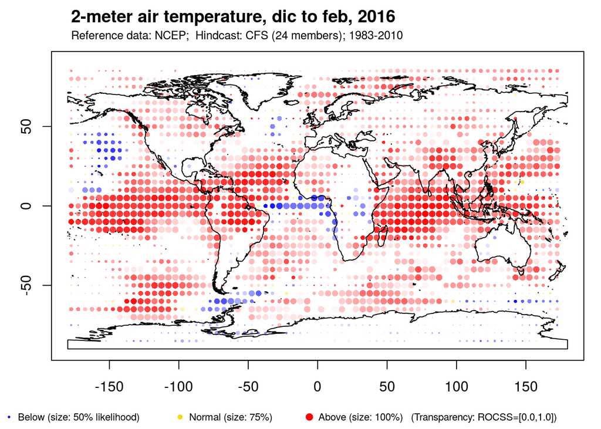

```r
bubblePlot(hindcast, obs, forecast = forecast,
           bubble.size = 1.5,
           subtitle = subtitle,
           size.as.probability = TRUE,
           score = TRUE
)
```

Note that many of the grid points correpsond to areas where the forecasting system exhibits few or no skill at all. It is often desirable to mask the areas where the forecast can not be trusted and focus on those where the user can have more confidence. This can also help to communicate the forecast to users with low level of expertise, so they don’t focus their attention in unreliable areas. A ROCSS `score.range` can be set to this aim:

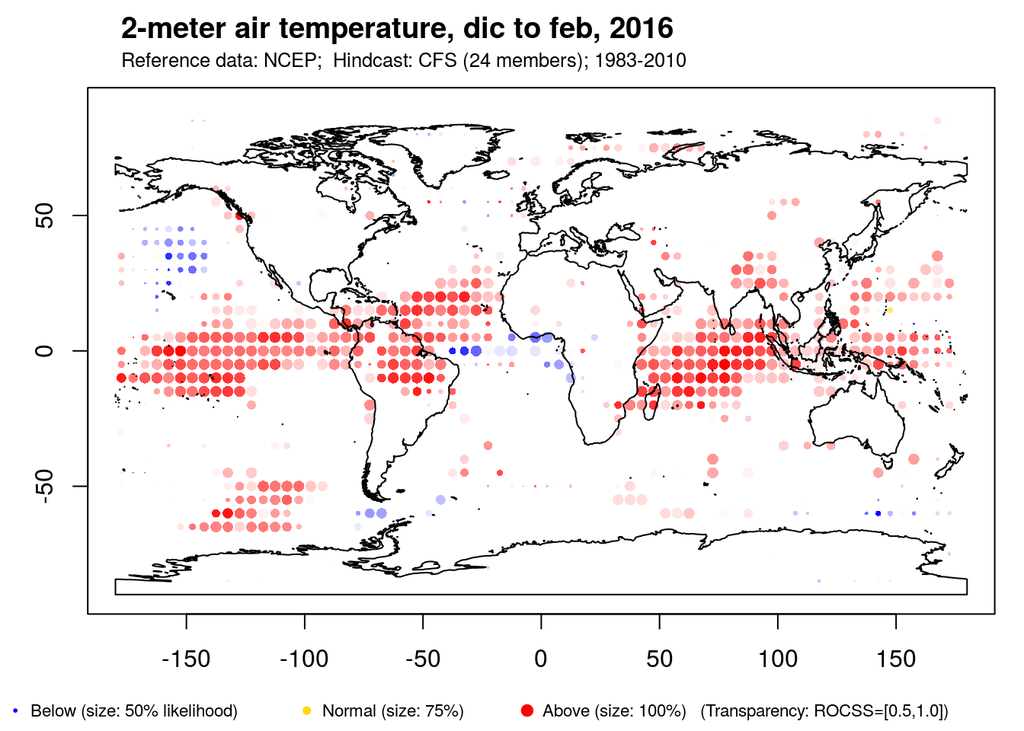

```r
bubblePlot(hindcast, obs, forecast = forecast,
           bubble.size = 1.5,
           subtitle = subtitle,
           size.as.probability = TRUE,
           score = TRUE,
           score.range = c(0.5, 1)
)
```

```r
# Cropping the North Atlantic region
crop.natl <- function(x) subsetGrid(x, lonLim = c(-80, 42), latLim = c(35, 72))
hindcast.natl <- crop.natl(hindcast)
forecast.natl <- crop.natl(forecast)
obs.natl <- crop.natl(obs)
```

The bubble plots with 3-piece pie charts are generated with the option `piechart = TRUE`.

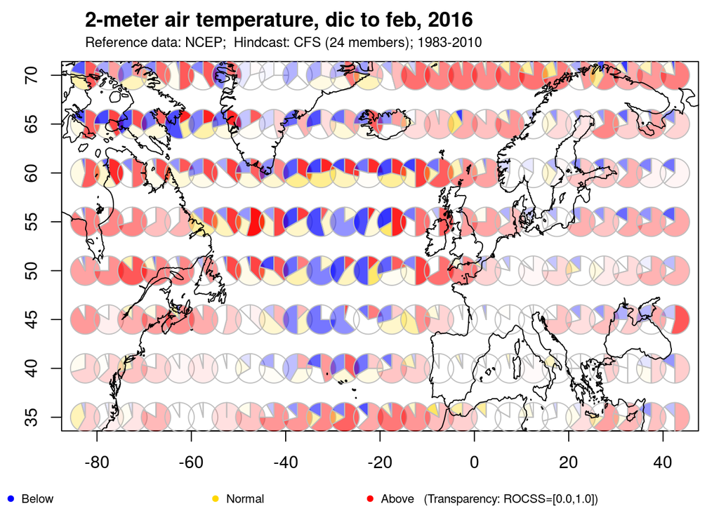

```r
bubblePlot(hindcast.natl, obs.natl, forecast = forecast.natl,
           bubble.size = 1.5,
           subtitle = subtitle,
           piechart = TRUE,
           score = TRUE
)
```

# 4 Tercile plots

To reproduce Figure 3 in Frías et al 2018, we firt crop the data considering the Niño 3.4 Region:

```r
crop.nino <- function(x) subsetGrid(x, lonLim = c(-170, -120), latLim = c(-5, 5))
hindcast.nino <- crop.nino(hindcast)
obs.nino <- crop.nino(obs)
forecast.nino <- crop.nino(forecast)
```

The tercile plot is next produced:

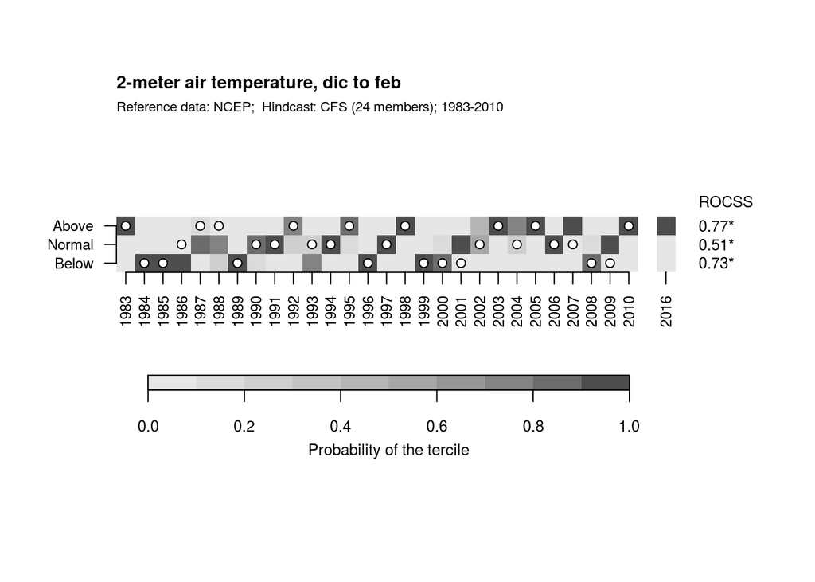

```r
tercilePlot(hindcast.nino, obs.nino, forecast = forecast.nino, subtitle = subtitle)
```

It is also possible to use tercile plots considering the forecast of a specific year of the forecast. For instance, in this case the `forecast` argument is set to `NULL` (the default), and we select year 1992 of the hindcast as the forecast (`year.target = 1992`):

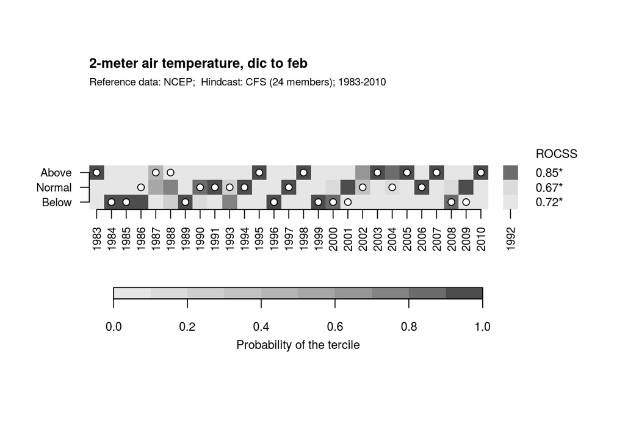

```r
tercilePlot(hindcast.nino, obs.nino, forecast = NULL, year.target = 1992, subtitle = subtitle)
```

# 5 Tercile bar plots

This code reproduces Figure 4 in Frías et al. 2018

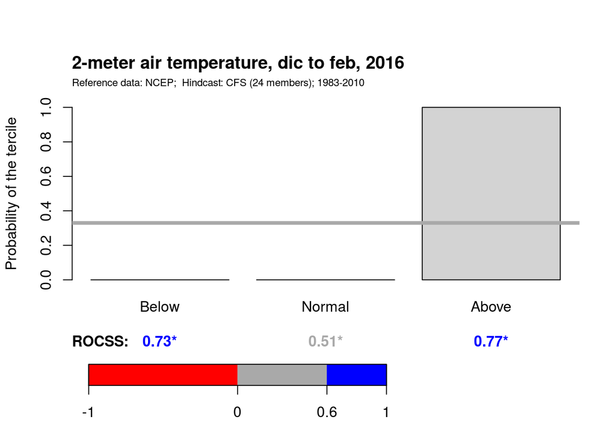

```r
# Plot for winter 2016 (forecast data)
tercileBarplot(hindcast.nino, obs.nino, forecast = forecast.nino, score.threshold = 0.6,
               subtitle = subtitle)
```

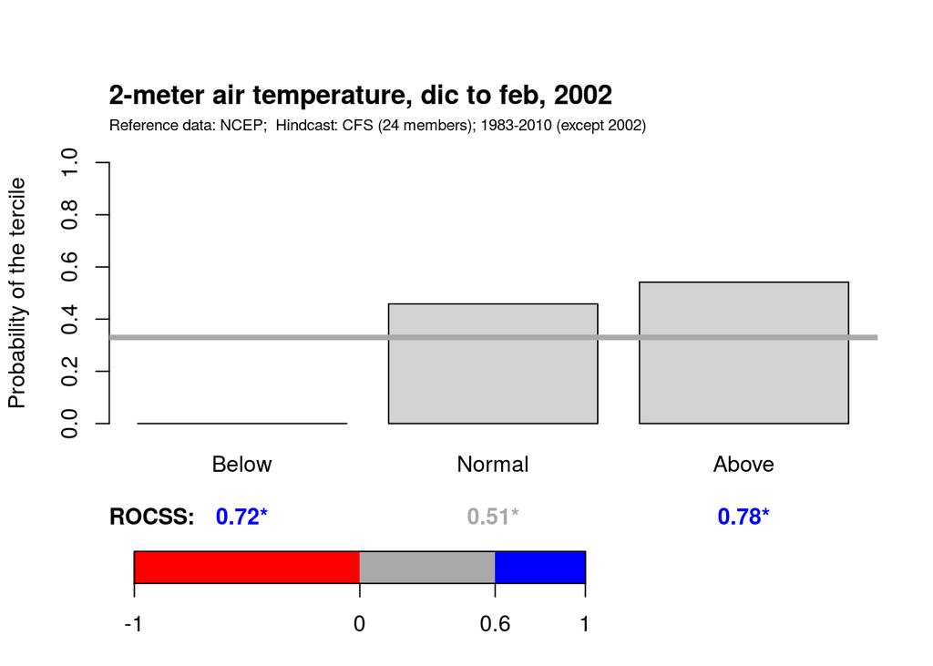

```r
# Plot for winter 2002 (selected from the hindcast)
year.target <- 2002
subtitle_year.target <- sprintf("Reference data: NCEP;  Hindcast: CFS (%d members); %d-%d (except %d)",
                                length(hindcast$Members), getYearsAsINDEX(hindcast)[1],
                                tail(getYearsAsINDEX(hindcast),1), year.target)
tercileBarplot(hindcast.nino, obs.nino, year.target = year.target, score.threshold = 0.6,
               subtitle = subtitle_year.target)
```

# 6 References

- Frías, M.D., Iturbide, M., Manzanas, R., Bedia, J., Fernández, J., Herrera, S., Cofiño, A.S., Gutiérrez, J.M., 2018. An R package to visualize and communicate uncertainty in seasonal climate prediction. Environmental Modelling & Software 99, 101–110. https://doi.org/10.1016/j.envsoft.2017.09.008
- Kalnay, E., Kanamitsu, M., Kistler, R., Collins, W., Deaven, D., Gandin, L., Iredell, M., Saha, S., White, G., Woollen, J., Zhu, Y., Leetmaa, A., Reynolds, R., Chelliah, M., Ebisuzaki, W., Higgins, W., Janowiak, J., Mo, K.C., Ropelewski, C., Wang, J., Jenne, R., Joseph, D., 1996. The NCEP/NCAR 40-Year Reanalysis Project. Bulletin of the American Meteorological Society 77, 437–471. https://doi.org/10.1175/1520-0477(1996)077<0437:TNYRP>2.0.CO;2
- Saha, S., Moorthi, S., Wu, X., Wang, J., Nadiga, S., Tripp, P., Behringer, D., Hou, Y.-T., Chuang, H., Iredell, M., Ek, M., Meng, J., Yang, R., Peña Mendez, M., van den Dool, H., Zhang, Q., Wang, W., Chen, M., Becker, E., 2013. The NCEP Climate Forecast System Version 2. J Clim 130925135638001. https://doi.org/10.1175/JCLI-D-12-00823.1